# WM-2026-02-19-supervisor-meeting

WM

2026-02-18

Hey everyone,

I’m trying out this format as an agenda for a meeting as it allows me to easily express my thoughts / ask questions supported by figures (e.g. from raw data or model results). It saves me quite some hassle as I can code / type in one document, and any updates to code/figures immediately get saved in a file that I can share with you, without me having to reshuffle slides, figures etc. If this format doesn’t work for you, let me know and I’ll find an alternative.

# Meeting agenda

- Update
- Administrative questions for Carsten:
  - Can I keep working on Mjölnir throughout the rest of the PhD? Or indefinitely until I don’t need it anymore and then sign off?
  - Can I apply for the research stay abroad from Copenhagen to try and get money for the relocation towards here? It’s much much more than Adelaide gives me (almost 10x!).
- Chapter 1:
  - Predictions from Atlas 1 to Atlas 2/3 are alright, but predictions from Atlas 2/3 to 1 are no better than random.
  - Does the inclusion of temperature / precipitation even make sense? An oyster-catching example.

# Chapter 1

### Predictions forward / backward in time

In the plot below you see three models, each trained on one of the atlases. Each dot represents one species, The X and Y axes compare explanatory power (metrics derived from training data) with predictive power (metrics derived from testing on validation data). Black dots show predictive power from 5-fold cross-validation on the same atlas, red and blue dots show predictive power from testing on a different atlas.

There’s a quite striking pattern that the first atlas predicts ‘okay’ in atlas 2 and atlas 3, and atlas 2 and atlas 3 predict ‘okay’ on each-other but predict basically random in atlas 1.

I’ve already discussed this a bit with Kasper. If I can speak on his behalf, he thinks this is driven by the fact that Atlas 1 has more variance explained by the spatial component (as we’ll see below), and this is spatial component is then ‘carrying the weight’ for predictions in later atlases (if I understood Kasper correctly). I think this is possible and will be testing this, but I personally find the differences in accuracies too big to be explained by such ‘little’ differences in variance explained.

To be quite honest, I can’t really explain this properly yet. I’m happy to discuss what this could mean.

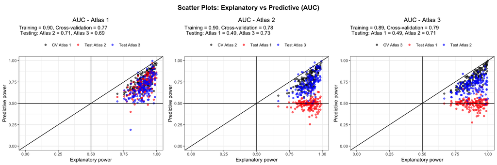

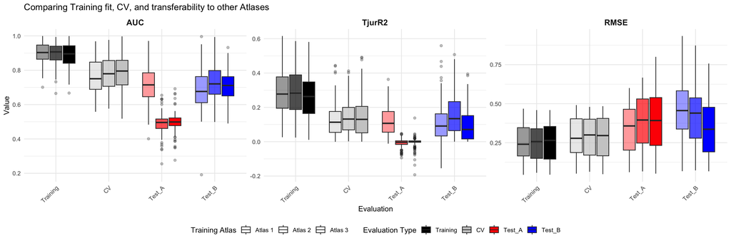

### Variance explained by land-use / climate

These models are trained on climate / land-use data. The variance explained by these different components looks like this. The top row shows the total variance explained by both environmental and random (spatial) effects. The bottom row excludes those spatial effects to look at patterns of environmental variables and their relative / absolute variance explained through time.

In terms of absolute variance explained, temperature, precipition and % forest cover do the most work explaining the data. Let’s look into those a bit further.

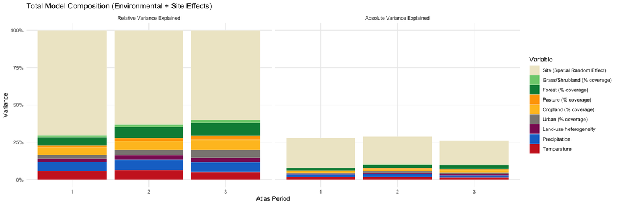

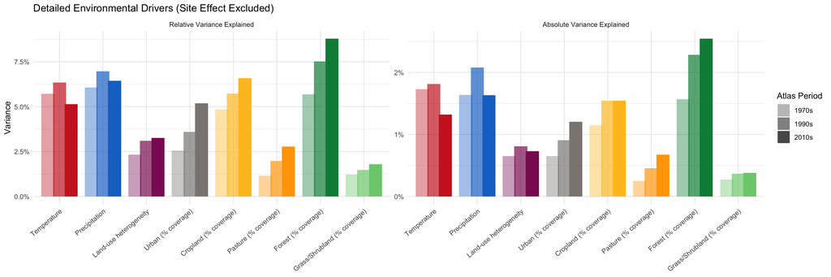

### Temperature

When we look at a bit closer detail at variance explained by temperature across species, we find that plovers on average have the highest variance explained by temperature, across all the guilds.

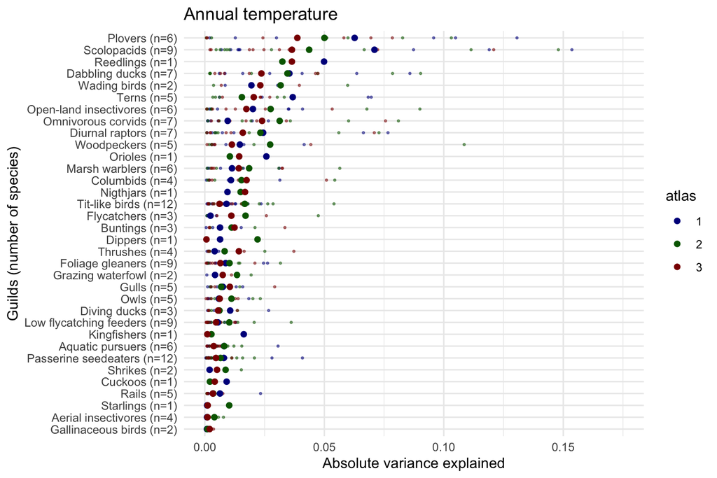

### Oystercatcher

We can look a bit more in detail at one of these species. The oystercatcher is one of the plovers with very high variance explained across all models.

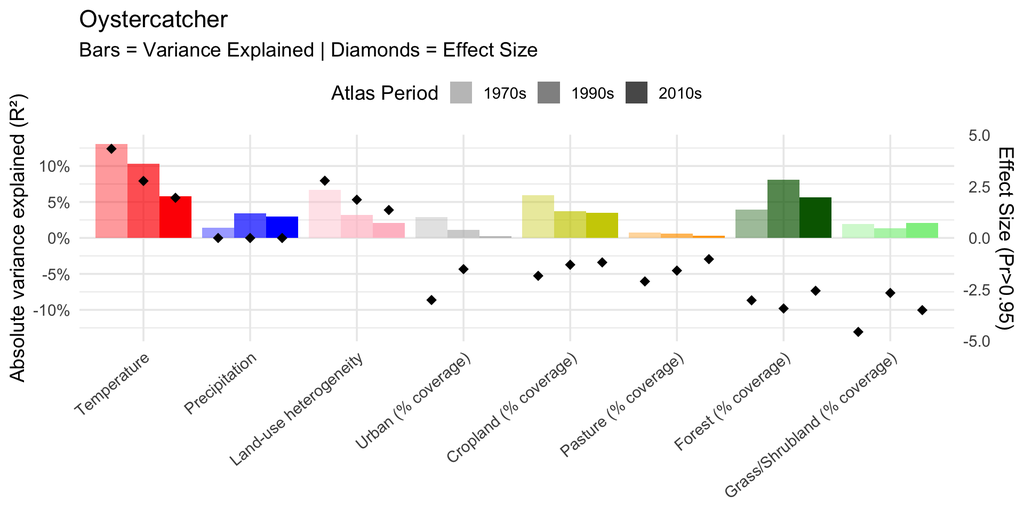

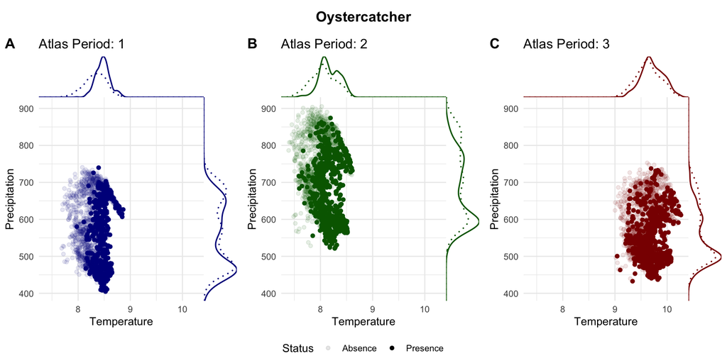

Quite likely the coastline! As we can see on the plots below, the coastlines are consistently warmer than than the middle of the country. This happens to be the locations that the oystercatchers inhabit. Overtime, they continuously move land-inwards, which maybe explains the decreasing variance explained / effect sizes that we saw two plots ago.

This reasoning maybe applies to other shore/wading birds as well, which explains why most of the guilds with highest variance explained by temperature are shore/wading birds.

If this is the case, it seems that what we’re modelling is not a species relationship to the environment, but a species’ preferred habitat to the environment. If so, does it even make sense to include these variables in the model?

Let’s discuss!

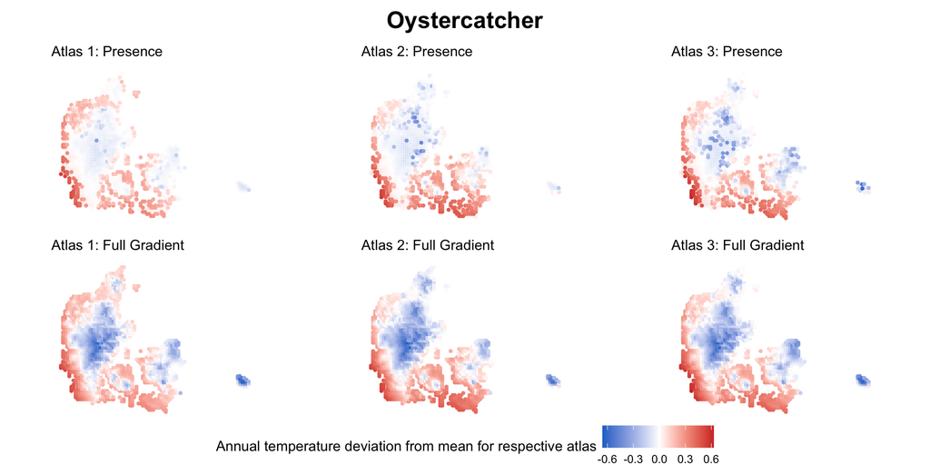

### Forest coverage

I’ll rerun this for the % coverage of forest because there’s a really nice relationship with some birds!

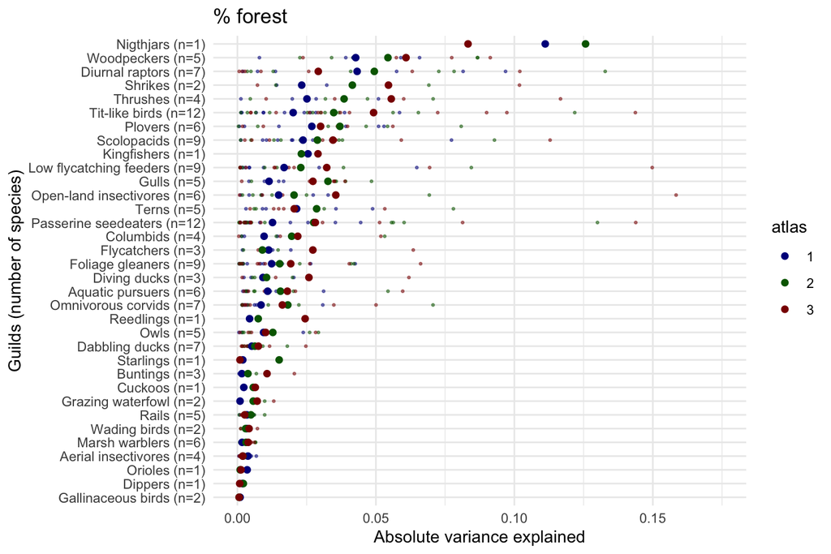

### Nightjar

We can look a bit more in detail at the nightjar. % coverage of forest seems to consistently have a profound positive effect on nightjars, explaining a lot of variation with high effect sizes. Higher coverage of croplands have a generally negative effect on the species.

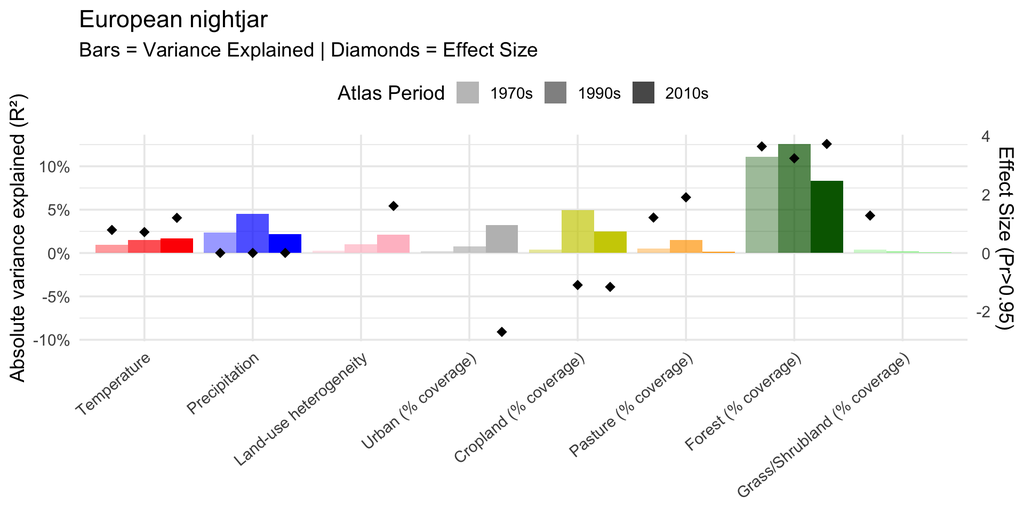

This is reflected in the environmental space also, mostly occupying grids with some % coverage of forest, and low % coverage of croplands.

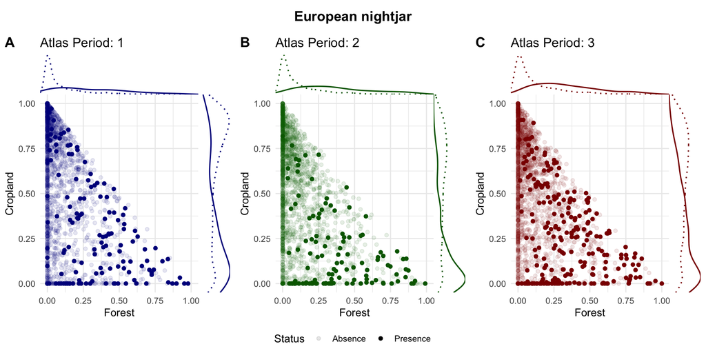

I really like these plots for this, as you can nicely see the ‘pockets’ of high % coverage of forest in each atlas, which very nicely match with the presences of the species.

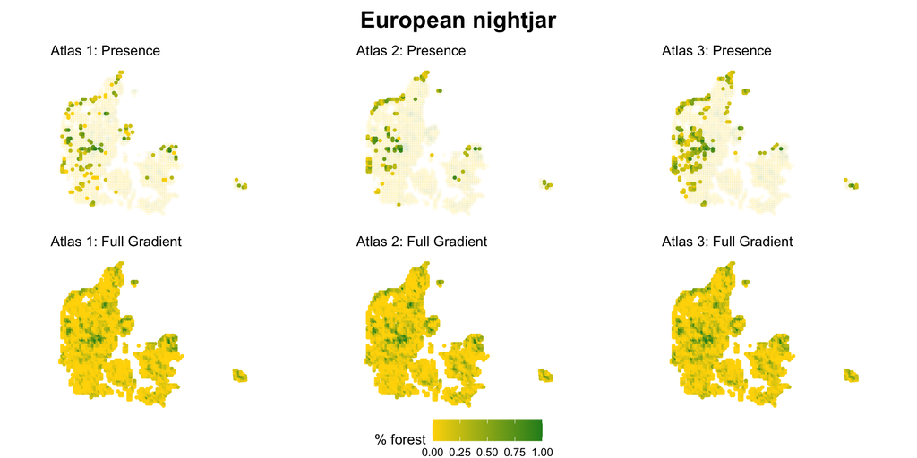